# Weekly survival by latitude, averaged across ROMS and taxa

A Fischbach

May 17, 2018

## Load the data

The dat.frame df_ee was built by the .3-weekly_survival-heat_map_by_latitude.R script, which summarized weekly survival into 1 degree latitudinal bands for all taxa, modeled across study years within each study period. Each row of this dat.frame represents survival across weeks (columns 1:53) for each taxon, model, and year (indicated in the columns ‘taxa’, ‘model’, and ‘year’). The column ‘studyPeriodOne’ is TRUE if year is part of the study period 2003-2012

```r
#baseDir <- 'D:/HelpingOthers/droghini/sea-invaders'
baseDir <- 'C:/Users/adroghini/Documents/Marine-invasives/PMEL-Models'
#load(file.path(baseDir, '/heatMap/week_survival_lat_taxa_model_studyPeriod.rData'))
load(file.path(baseDir, '/rOut/week_survival_lat_taxa_model_studyPeriod.rData'))
cat(nrow(df_ee), 'rows of data read in from', length(unique(df_ee$taxa)), 'taxa', fill =T)
```

```
## 40320 rows of data read in from 42 taxa
```

```r
glimpse(df_ee)
```

```
## Observations: 40,320
## Variables: 58
## $ Week_01        <dbl> 1, 1, 1, 1, 1, 1, 1, 1, 1, 1, 0, 0, 0, 0, 0, 0,...
## $ Week_02        <dbl> 1, 1, 1, 1, 1, 1, 1, 1, 1, 0, 0, 0, 0, 0, 0, 0,...
## $ Week_03        <dbl> 1, 1, 1, 1, 1, 1, 1, 1, 1, 0, 0, 0, 0, 0, 0, 0,...
## $ Week_04        <dbl> 1, 1, 1, 1, 1, 1, 1, 1, 1, 0, 0, 0, 0, 0, 0, 0,...
## $ Week_05        <dbl> 1, 1, 1, 1, 1, 1, 1, 1, 1, 0, 0, 0, 0, 0, 0, 0,...
## $ Week_06        <dbl> 1, 1, 1, 1, 1, 1, 1, 1, 1, 0, 0, 0, 0, 0, 0, 0,...
## $ Week_07        <dbl> 1, 1, 1, 1, 1, 1, 1, 1, 1, 0, 0, 0, 0, 0, 0, 0,...
## $ Week_08        <dbl> 0, 1, 1, 1, 1, 1, 1, 1, 1, 0, 0, 0, 0, 0, 0, 0,...
## $ Week_09        <dbl> 0, 1, 1, 1, 1, 1, 1, 1, 1, 0, 0, 0, 0, 0, 0, 0,...
## $ Week_10        <dbl> 0, 1, 1, 1, 1, 1, 1, 1, 1, 0, 0, 0, 0, 0, 0, 0,...
## $ Week_11        <dbl> 0, 1, 1, 1, 1, 1, 1, 1, 1, 1, 0, 0, 0, 0, 0, 0,...
## $ Week_12        <dbl> 0, 1, 1, 1, 1, 1, 1, 1, 1, 1, 0, 0, 0, 0, 0, 0,...
## $ Week_13        <dbl> 0, 1, 1, 1, 1, 1, 1, 1, 1, 1, 0, 0, 0, 0, 0, 0,...
```

[output cut: 45 more lines]

## Reshape the data

Reshape into long form with a column for weeks, a column for latitudinal bands, and the columns for the taxa, model, year and study period.

```r
    df_tidy <- df_ee %>%
            gather(key = Week, value = survival, -taxa, -model, -studyPeriodOne, -lat, -year)
    df_tidy$Week <- as.numeric(substr(df_tidy$Week, start = 6, stop = 7))
    df_tidy$lat <- as.numeric(df_tidy$lat)
  glimpse(df_tidy)
```

```
## Observations: 2,136,960
## Variables: 7
## $ lat            <dbl> 51, 52, 53, 54, 55, 56, 57, 58, 59, 60, 61, 62,...
## $ taxa           <chr> "Alosa.sapidissima", "Alosa.sapidissima", "Alos...
## $ model          <chr> "CCCma", "CCCma", "CCCma", "CCCma", "CCCma", "C...
## $ year           <dbl> 2003, 2003, 2003, 2003, 2003, 2003, 2003, 2003,...
## $ studyPeriodOne <lgl> TRUE, TRUE, TRUE, TRUE, TRUE, TRUE, TRUE, TRUE,...
## $ Week           <dbl> 1, 1, 1, 1, 1, 1, 1, 1, 1, 1, 1, 1, 1, 1, 1, 1,...
## $ survival       <dbl> 1, 1, 1, 1, 1, 1, 1, 1, 1, 1, 0, 0, 0, 0, 0, 0,...
```

```r
  summary(df_tidy)
```

```
##       lat            taxa              model                year
##  Min.   :51.00   Length:2136960     Length:2136960     Min.   :2003
##  1st Qu.:54.75   Class :character   Class :character   1st Qu.:2008
##  Median :58.50   Mode  :character   Mode  :character   Median :2021
##  Mean   :58.50                                         Mean   :2021
##  3rd Qu.:62.25                                         3rd Qu.:2034
##  Max.   :66.00                                         Max.   :2039
##
##  studyPeriodOne       Week       survival
##  Mode :logical   Min.   : 1   Min.   :0.00
##  FALSE:1068480   1st Qu.:14   1st Qu.:1.00
##  TRUE :1068480   Median :27   Median :1.00
##                  Mean   :27   Mean   :0.84
##                  3rd Qu.:40   3rd Qu.:1.00
##                  Max.   :53   Max.   :1.00
##                               NA's   :52416
```

## Sumarize the data

Summary plot of mean survival over all taxa by StudyPeriod (False = future, True = current) and latitudinal band.

Take the mean of weekly survival across each year within each study period.

If that mean is >= 0.7, classify the latitudinal band as having habitat (1, 0 otherwise).

This 7/10 threshold is the same threshold that was used to define year-round survival.

```r
# Within a taxon-model-study period, and for each week:
# How many years are predicted to have suitable habitat?
  df_byPeriodModel <- df_tidy %>%
    mutate(Period = as.integer(!studyPeriodOne) ) %>%
    group_by(Period, taxa, Week, lat, model) %>%
    summarize(nSurvival = sum(survival, na.rm = T))
  glimpse(df_byPeriodModel)
```

```
## Observations: 213,696
## Variables: 6
## $ Period    <int> 0, 0, 0, 0, 0, 0, 0, 0, 0, 0, 0, 0, 0, 0, 0, 0, 0, 0...
## $ taxa      <chr> "Alosa.sapidissima", "Alosa.sapidissima", "Alosa.sap...
## $ Week      <dbl> 1, 1, 1, 1, 1, 1, 1, 1, 1, 1, 1, 1, 1, 1, 1, 1, 1, 1...
## $ lat       <dbl> 51, 51, 51, 52, 52, 52, 53, 53, 53, 54, 54, 54, 55, ...
## $ model     <chr> "CCCma", "ECHOG", "MIROC", "CCCma", "ECHOG", "MIROC"...
## $ nSurvival <dbl> 3, 1, 4, 10, 7, 10, 10, 9, 9, 10, 8, 10, 10, 10, 10,...
```

```r
  summary(df_byPeriodModel)
```

```
##      Period        taxa                Week         lat
##  Min.   :0.0   Length:213696      Min.   : 1   Min.   :51.00
##  1st Qu.:0.0   Class :character   1st Qu.:14   1st Qu.:54.75
##  Median :0.5   Mode  :character   Median :27   Median :58.50
##  Mean   :0.5                      Mean   :27   Mean   :58.50
##  3rd Qu.:1.0                      3rd Qu.:40   3rd Qu.:62.25
##  Max.   :1.0                      Max.   :53   Max.   :66.00
##     model             nSurvival
##  Length:213696      Min.   : 0.000
##  Class :character   1st Qu.: 9.000
##  Mode  :character   Median :10.000
##                     Mean   : 8.162
##                     3rd Qu.:10.000
##                     Max.   :10.000
```

```r
# Is number of years >= 7?
  df_byPeriodModelClass <-df_byPeriodModel %>%
                          mutate(survival = if_else(nSurvival >= 7, 1, 0))
```

Average across the 3 ROMS models

```r
  df_byPeriodTaxa <- df_byPeriodModelClass %>%
    group_by(Period, taxa, Week, lat) %>%
    summarize(MeanAcrossModelsSurvival = mean(survival, na.rm = T))
  glimpse(df_byPeriodTaxa)
```

```
## Observations: 71,232
## Variables: 5
## $ Period                   <int> 0, 0, 0, 0, 0, 0, 0, 0, 0, 0, 0, 0, 0...
## $ taxa                     <chr> "Alosa.sapidissima", "Alosa.sapidissi...
## $ Week                     <dbl> 1, 1, 1, 1, 1, 1, 1, 1, 1, 1, 1, 1, 1...
## $ lat                      <dbl> 51, 52, 53, 54, 55, 56, 57, 58, 59, 6...
## $ MeanAcrossModelsSurvival <dbl> 0.0000000, 1.0000000, 1.0000000, 1.00...
```

```r
  summary(df_byPeriodTaxa)
```

```
##      Period        taxa                Week         lat
##  Min.   :0.0   Length:71232       Min.   : 1   Min.   :51.00
##  1st Qu.:0.0   Class :character   1st Qu.:14   1st Qu.:54.75
##  Median :0.5   Mode  :character   Median :27   Median :58.50
##  Mean   :0.5                      Mean   :27   Mean   :58.50
##  3rd Qu.:1.0                      3rd Qu.:40   3rd Qu.:62.25
##  Max.   :1.0                      Max.   :53   Max.   :66.00
##  MeanAcrossModelsSurvival
##  Min.   :0.0000
##  1st Qu.:1.0000
##  Median :1.0000
##  Mean   :0.8089
##  3rd Qu.:1.0000
##  Max.   :1.0000
```

Summarize across taxa

```r
  df_byPeriod <- df_byPeriodTaxa %>%
               group_by(Period, Week, lat) %>%
               summarize(speciesRichness = sum(MeanAcrossModelsSurvival, na.rm = T))
  glimpse(df_byPeriod)
```

```
## Observations: 1,696
## Variables: 4
## $ Period          <int> 0, 0, 0, 0, 0, 0, 0, 0, 0, 0, 0, 0, 0, 0, 0, 0...
## $ Week            <dbl> 1, 1, 1, 1, 1, 1, 1, 1, 1, 1, 1, 1, 1, 1, 1, 1...
## $ lat             <dbl> 51, 52, 53, 54, 55, 56, 57, 58, 59, 60, 61, 62...
## $ speciesRichness <dbl> 35.00000, 37.00000, 37.00000, 37.00000, 37.000...
```

```r
  summary(df_byPeriod)
```

```
##      Period         Week         lat        speciesRichness
##  Min.   :0.0   Min.   : 1   Min.   :51.00   Min.   : 0.00
##  1st Qu.:0.0   1st Qu.:14   1st Qu.:54.75   1st Qu.:33.67
##  Median :0.5   Median :27   Median :58.50   Median :36.33
##  Mean   :0.5   Mean   :27   Mean   :58.50   Mean   :33.97
##  3rd Qu.:1.0   3rd Qu.:40   3rd Qu.:62.25   3rd Qu.:39.67
##  Max.   :1.0   Max.   :53   Max.   :66.00   Max.   :42.00
```

## Plot

For each week and degree of latitude within the Bering Sea shelf, depict the mean survival across taxa averaged across years and models during the two study periods.

Technical plotting issues:

1. Need to generate a meaningful time label on the x-axis (day of year, sensible grid lines every 1st day of every other month?)
2. Need a suitable plot grid to be in the foreground. Perhaps a thin green line may work with the viridis::plasma pallet.
3. Need to improve the legend text, and numeric labels Done?

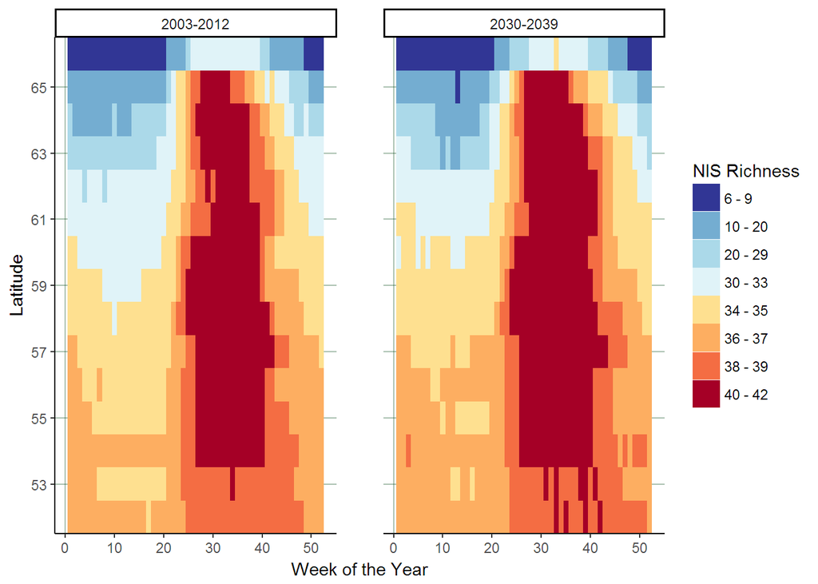

```r
  color.pal <- brewer.pal(11,"RdYlBu")[c(11,9,8,7,5,4,3,1)]
 #the.breaks<-c(-1,20,30,35,37,40,42)
the.breaks<-c(5,10,20,30,34,36,38,40,42) #no pixel predicted to have NIS < 5
  the.labels<-c("6 - 9","10 - 20", "20 - 29", "30 - 33","34 - 35", "36 - 37", "38 - 39", "40 - 42") #breaks are (inclusive,excluded] Starts at 5 but minimum NIS richness is 5.66 and I'm rounding up to nearest integer for legend clarity
  df_byPeriod %>%
    mutate(spRichf=cut(speciesRichness,breaks=the.breaks)) %>%
    mutate(periodf=factor(Period,levels=c(0,1),labels=c("2003-2012","2030-2039"))) %>%
    subset(Week<53 & lat > 51) %>%
    #subset to make the plot prettier
    #remove 53 weeks - doesn't happen every year so it's not out of 10 (removes right-most vertical band of no species richness across all latitudes)
    #remove latitude 51 (so few pixels that you end up getting little survival predicted)
    ggplot(aes(Week, lat, as.factor(spRichf))) +
    geom_tile(aes(fill = as.factor(spRichf))) +
   scale_fill_manual(values=color.pal,name="NIS Richness",labels=factor(the.labels)) +
    #scale_fill_manual(values=color.pal,name=factor(the.breaks)) +
    scale_y_continuous(breaks=seq(from=51,to=67,by=2),name="Latitude",expand=c(0,0))+
    scale_x_continuous(breaks=seq(from=0,to=50,by=10),name="Week of the Year")+
    theme_classic() +
    theme(legend.direction = "vertical",
        legend.title = element_text('NIS Richness'),
         panel.spacing = unit(2, "lines"), #sets spacing between facet panels
         panel.grid.major = element_line(size = 0.5, colour = '#00441155')) +
    facet_wrap(~periodf)
```

```r
#ggsave("plots/heatmap_weekly_survival.png", plot = last_plot(), width = 7, height = 4, units = "in",dpi = 300)
  #ran separately - ggsave not working inside RMarkdown?
```

Plot only current period (2003-2012)

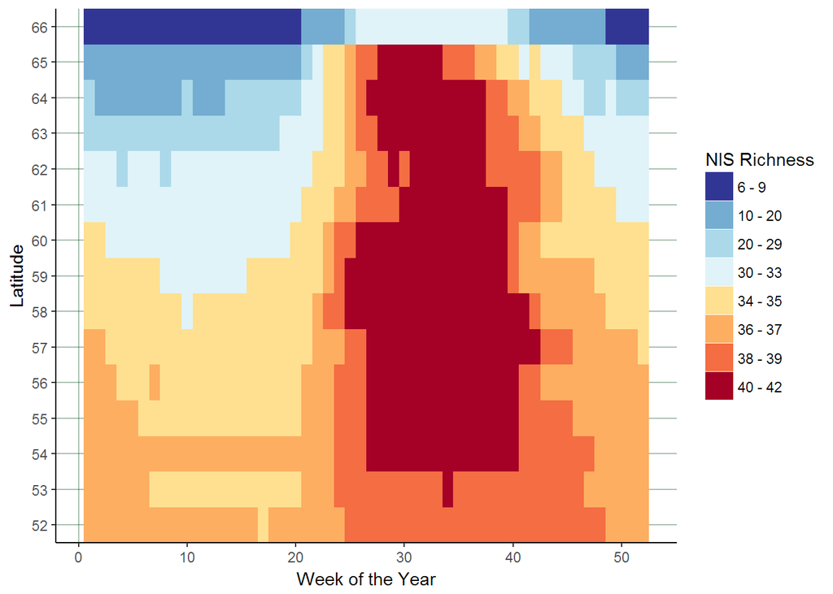

```r
  color.pal <- brewer.pal(11,"RdYlBu")[c(11,9,8,7,5,4,3,1)]
 #the.breaks<-c(-1,20,30,35,37,40,42)
the.breaks<-c(5,10,20,30,34,36,38,40,42)
  the.labels<-c("6 - 9","10 - 20", "20 - 29", "30 - 33","34 - 35", "36 - 37", "38 - 39", "40 - 42")
  #breaks are (inclusive,excluded] Starts at 5 but minimum NIS richness is 5.66 and I'm rounding up to nearest integer for legend clarity
  df_byPeriod %>%
    mutate(spRichf=cut(speciesRichness,breaks=the.breaks)) %>%
    mutate(periodf=factor(Period,levels=c(0,1),labels=c("2003-2012","2030-2039"))) %>%
    subset(Week<53 & lat > 51 & Period=="0") %>%
    #subset to make the plot prettier
    #remove 53 weeks - doesn't happen every year so it's not out of 10 (removes right-most vertical band of no species richness across all latitudes)
    #remove latitude 51 (so few pixels that you end up getting little survival predicted)
    ggplot(aes(Week, lat, as.factor(spRichf))) +
    geom_tile(aes(fill = as.factor(spRichf))) +
   scale_fill_manual(values=color.pal,name="NIS Richness",labels=factor(the.labels)) +
    #scale_fill_manual(values=color.pal,name=factor(the.breaks)) +
    scale_y_continuous(breaks=seq(from=51,to=67,by=1),name="Latitude",expand=c(0,0))+
    scale_x_continuous(breaks=seq(from=0,to=50,by=10),name="Week of the Year")+
    theme_classic() +
    theme(legend.direction = "vertical",
        legend.title = element_text('NIS Richness'),
         panel.spacing = unit(2, "lines"), #sets spacing between facet panels
         panel.grid.major = element_line(size = 0.5, colour = '#00441155'))
```

```r
    #facet_wrap(~periodf)

##ggsave("plots/heatmap_weekly_period1.png", plot = last_plot(), width = 6, height = 4, units = "in",dpi = 300)
```